# Data processing for supplementary materials

Authors

Affiliations

Elena Sheard

New Zealand Institute of Language, Brain and Behaviour, University of Canterbury

Jen Hay

New Zealand Institute of Language, Brain and Behaviour, University of Canterbury

Department of Linguistics, University of Canterbury

Joshua Wilson Black

New Zealand Institute of Language, Brain and Behaviour, University of Canterbury

Robert Fromont

New Zealand Institute of Language, Brain and Behaviour, University of Canterbury

Lynn Clark

New Zealand Institute of Language, Brain and Behaviour, University of Canterbury

Department of Linguistics, University of Canterbury

Published

February 26, 2025

# 1 Overview

This file generates the data frames used in the supplementary materials for the manuscript “Do ‘leaders’ sound different from ‘laggers’? Exploring the perceptual similarity of New Zealand English voices”. The materials can be viewed [here](https://nzilbb.github.io/qb-pairwise-public/Markdown/Supplementary-materials-script.html).

This script **(a)** scales the raw similarity ratings per participant and **(b)** generates the similarity matrices for MDS analysis. The script applies **(a)** and **(b)** to the responses filtered as reported (Section 3) and as pre-registered (Section 4). The script also applies **(a)** to the unfiltered data (Section 5), which is used in the supplementary materials to discuss the reported filtering.

# 2 Libraries and data

The chunk below loads the libraries used in this script.

**Click here to view code.**

```r
# Data wrangling
library(tidyverse)
library(data.table)

# Other
library(here) # localised file paths

# Set theme for visualisations
theme_set(theme_bw())

# Date is used for generating file names.
date <- "250124"
```

The next chunk loads:

- The anonymised pairwise ratings from the online task
- A data frame that contains all possible pairwise combinations of the 38 stimuli, with IDs for each pair (ordered and unordered). This data frame is used to generate the similarity matrices.

**Click here to view code.**

```r
# Experiment results and demographic info
df_anon <-
  read_rds(
    here(
      "Data",
      "PW_cleaned_anon_250124.rds"
    )
  )

# Convert ratings to numeric
df_anon <- df_anon %>%
  mutate(
    enteredResponse = as.numeric(enteredResponse)
  )

# Df containing all pairwise combinations with IDs
combinations_anon <- read_rds(
  here("Data", "PW_combinations_anon_250124.rds")
)
```

The next block:

- Calculates the range of pairwise rating values for each participant
- Calculates the number of maximum and minimum values used by each participant (i.e., how many 0s and 1s).
- Calculates the total number of responses for each participant.
- Generates Figure 1, which displays the distribution of the calculated rating ranges.

**Click here to view code.**

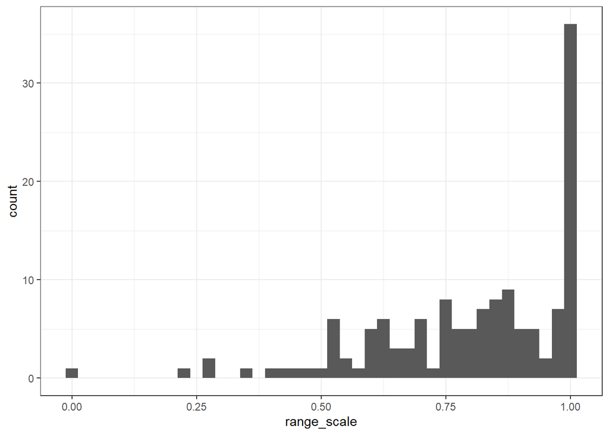

Figure 1: Distribution of participant rating ranges

```r
worker_summary_df_anon <- df_anon %>%
  group_by(workerId) %>%
  summarise(
    range_scale = max(enteredResponse) - min(enteredResponse),
    count_0 = sum(enteredResponse == 0),
    count_1 = sum(enteredResponse == 1),
    responses = n()
  )

worker_summary_df_anon %>%
  ggplot(aes(x = range_scale)) +
  geom_histogram(binwidth = 0.025)
```

Figure 1 shows that, for instance, the total range of the slider is used by 36 participants, with almost all participants using at least 50% of the slider.

# 3 Reported data

## 3.1 Participant filtering

Remove listeners who:

- Use a range smaller than 0.25 of the scale.
- Exclusively uses the extremes.

This policy is applied in the block below (see Section 7, “Discussing data exclusions”, in the supplementary materials for motivations).

**Click here to view code.**

```r
to_remove_reported <- worker_summary_df_anon %>%
  mutate(extreme_count = count_0 + count_1) %>%
  filter(
    range_scale < 0.25 | extreme_count >= 34
  ) %>%
  pull(workerId)

df_anon_filtered <- df_anon %>%
  filter(!workerId %in% to_remove_reported)
```

## 3.2 Scaling similarity ratings per participant

In the code block below we z-score the participant similarity ratings. Z-scoring centers participant values on 0. Because the similarity matrix for MDS analysis requires all values to be above 0 (i.e., the analysis cannot be applied to negative values), we also add the absolute value of the minimum scaled response value to all of the response. This way, the lowest rating goes to 0, and all ratings are above 0.

**Click here to view code.**

```r
df_anon_filtered_scaled <- df_anon_filtered %>%
  group_by(workerId) %>%
  mutate(
    enteredResponse = as.numeric(enteredResponse),
    # First: z-score responses
    scaledResponse = scale(enteredResponse, center = TRUE, scale = TRUE)
  ) %>%
  # Second: Add the absolute value of the minimum response value to all of the
  # responses. We ungroup because we need the global minimum, not the minumum
  # for each participant.
  ungroup() |>
  mutate(ReScaledResponse = scaledResponse + abs(min(scaledResponse)))
```

We then save the scaled ratings as an `.rds` file.

**Click here to view code.**

```r
file_name_ratings_ID_anon <-
  paste0("PW_ratings_scaled_filtered_anon_", date, ".rds", sep = "")

write_rds(
  df_anon_filtered_scaled,
  here(
    "Data",
    file_name_ratings_ID_anon
  )
)
```

## 3.3 Similarity matrix based on scaled ratings

To apply MDS, we require a square matrix with a *single* measure of similarity for each pair of speakers. As we have multiple ratings per speaker pair, we first need to generate a single value to be the input for the matrix. The code chunk below takes the mean for each speaker pair from the scaled similarity ratings, and then creates a 38 x 38 matrix of the mean values.

**Click here to view code.**

```r
PW_means_anon <- df_anon_filtered_scaled %>%
  group_by(pair_id_unordered) %>%
  summarise(MeanScaledResponse = mean(ReScaledResponse)) %>%
  right_join(combinations_anon,
      by = c("pair_id_unordered")
  )

# Convert to wide df
sim_matrix_anon <-
  reshape2::dcast(PW_means_anon, Stimuli1ID ~ Stimuli2ID, value.var = "MeanScaledResponse")

# Convert to matrix
sim_matrix_anon <-
  sim_matrix_anon %>%
  remove_rownames() %>%
  column_to_rownames(var = "Stimuli1ID") %>%
  as.matrix()
```

We then save the matrix as an `.rds` file.

**Click here to view code.**

```r
file_name_matrix_ID_anon <-
  paste0("PW_matrix_scaled_anon_", date, ".rds", sep = "")

write_rds(
  sim_matrix_anon,
  here(
    "Data",
    file_name_matrix_ID_anon
  )
)
```

# 4 Data filtered based on pre-registration

This section creates the same data frames as Section 3 but applies the pre-registered filtering.

## 4.1 Participant filtering

The code chunk below removes participants whose range of rating values is 2.5 standard deviations above or below the mean.

**Click here to view code.**

```r
to_remove_prereg <- worker_summary_df_anon %>%
  mutate(SD_indicate_range = case_when(
    range_scale > (
      mean(range_scale, na.rm = TRUE) + 2.5 * sd(range_scale, na.rm = TRUE)
    ) |
      range_scale < (
        mean(range_scale, na.rm = TRUE) - 2.5 * sd(range_scale, na.rm = TRUE)
      ) ~ TRUE,
    T ~ FALSE
  )) %>%
  filter(
    SD_indicate_range == TRUE
  ) %>%
  pull(workerId)

df_anon_prereg_filtered <- df_anon %>%
  filter(!workerId %in% to_remove_prereg)
```

## 4.2 Scaling similarity ratings per participant

The next code chunks apply the same scaling procedure as Section 3.2 to our pre-registered filtering, and save the scaled ratings as an `.rds` file.

**Click here to view code.**

```r
df_anon_prereg_filtered_scaled <- df_anon_prereg_filtered %>%
  group_by(workerId) %>%
  mutate(
    enteredResponse = as.numeric(enteredResponse),
    scaledResponse = scale(enteredResponse, center = TRUE, scale = TRUE)
  ) %>%
  ungroup() |>
  mutate(ReScaledResponse = scaledResponse + abs(min(scaledResponse)))
```

**Click here to view code.**

```r
file_name_ratings_prereg_anon <-
  paste0("PW_ratings_scaled_PR_anon_", date, ".rds", sep = "")

write_rds(
  df_anon_prereg_filtered_scaled,
  here(
    "Data",
    file_name_ratings_prereg_anon
  )
)
```

## 4.3 Similarity matrix based on mean scaled ratings

We now create a second similarity matrix from the pre-registered filtering, and save this matrix as an `.rds` file.

**Click here to view code.**

```r
PW_means_prereg_anon <- df_anon_prereg_filtered_scaled %>%
  group_by(pair_id_unordered) %>%
  summarise(MeanScaledResponse = mean(ReScaledResponse)) %>%
  right_join(combinations_anon,
    by = c("pair_id_unordered")
  )

# Convert to wide df
sim_matrix_prereg <-
  reshape2::dcast(PW_means_prereg_anon, Stimuli1ID ~ Stimuli2ID, value.var = "MeanScaledResponse")

# Convert to matrix
sim_matrix_prereg <-
  sim_matrix_prereg %>%
  remove_rownames() %>%
  column_to_rownames(var = "Stimuli1ID") %>%
  as.matrix()
```

**Click here to view code.**

```r
file_name_matrix_prereg_anon <-
  paste0("PW_matrix_scaled_PR_anon_", date, ".rds", sep = "")

write_rds(
  sim_matrix_prereg,
  here(
    "Data",
    file_name_matrix_prereg_anon
  )
)
```

# 5 Unfiltered ratings

This final section applies the scaling procedure applied in Section 3.2 and Section 4.2 to the unfiltered data, as the unfiltered data is used for discussion in the supplementary materials.

## 5.1 Scaling similarity ratings per participant

**Click here to view code.**

```r
df_unfiltered <- df_anon %>%
  group_by(workerId) %>%
  mutate(
    enteredResponse = as.numeric(enteredResponse),
    scaledResponse = scale(enteredResponse, center = TRUE, scale = TRUE)
  ) %>%
  ungroup() |>
  mutate(ReScaledResponse = scaledResponse + abs(min(scaledResponse)))
```

**Click here to view code.**

```r
file_name_ratings_ID_unfiltered_anon <-
  paste0("PW_ratings_scaled_unfiltered_anon_", date, ".rds", sep = "")

write_rds(
  df_unfiltered,
  here(
    "Data",
    file_name_ratings_ID_unfiltered_anon
  )
)
```